# PEC3

Yury Postnikov

12/22/2021

# Ejercicio 1 Buscar un conjunto de datos relacionados con la Bioestadística o la Bioinformática.

Para nuestro trabajo hemos elegido la base de datos pública, que hemos encontrado en el sitio web kaggle.com:

https://www.kaggle.com/uciml/biomechanical-features-of-orthopedic-patients

Esta dataset tiene 2 archivos .csv (column_2C_weka y column_3C_weka), que se puede juntar y valorar conjuntamente: Es una base de datos que contiene informacaión sobre 310 personas, en las que evaluaron posición de vertebras de la columna lumbar utilizando varios parametros (tabla 1) y exolicación visual con la imagen del articulo^1. Dentro de esta muestra habia 100 personas que consideramos “sanos” o “normales” y 210 (“anormales”) que consideramos que tenian algun tipo de patología: “hernia” o “spondilolistesis”.

tabla 1:

| Variable | Expicación del variable |
| --- | --- |
| pelvic_incidence | Angulo entre la línea que pasa del centro de la lámina terminal del S1 al centro de las cabezas femorales, y la línea perpendicula a la lámina terminal de S1 |
| pelvic_tilt | Angulo entre la línea que pasa del centro de la lámina terminal del S1 al centro de las cabezas femorales y una línea vertical |
| lumbar_lordosis_angle | angulo entre la lámina terminal superior del L1 y S1 |
| sacral_sclope | angulo entre la línea perpendicula a la lámina terminal de S1 y una línea horizontal |
| pelvic_radius | Es un angulo entre la línea vertical y una línea del centro de las cabezas femorales hasta el borde posterior de la lámina terminal de S1 |
| degree_spondylolysthesis | distancia de desplazamiento de la vertebrq superior sobre la vertebra inferior (positivo - anterior y negativo - posterior) |
| class |  |
| class_2c | Classificación de data como “normal” y “anoraml” |
| class_3c | Classificación de data como “normal”, “Hernia” y “spondilolistesis” |

En esta imagen presentaremos la visualización de lo angulos medidas en la base de datos.

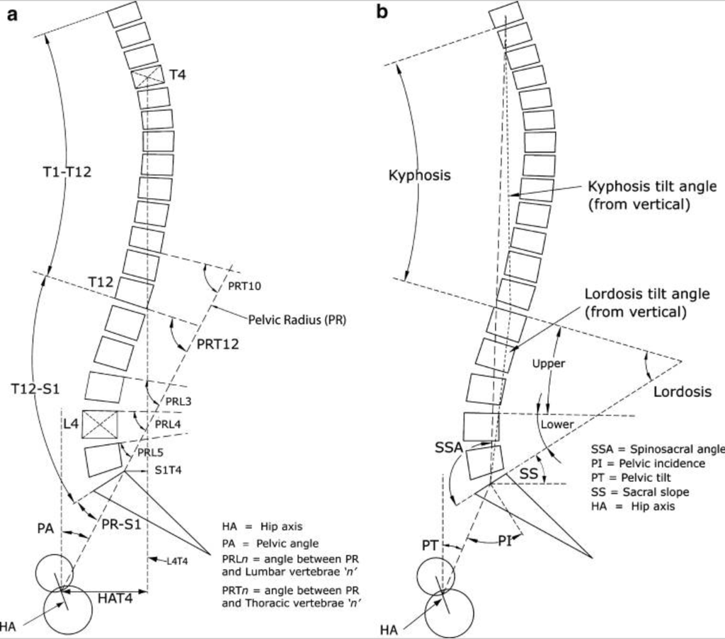

Las bibliografía:

1. Sergides IG, McCombe PF, White G, Mokhtar S, Sears WR. Lumbo-pelvic lordosis and the pelvic radius technique in the assessment of spinal sagittal balance: strengths and caveats. Eur Spine J. 2011;20 Suppl 5(Suppl 5):591-601. doi:10.1007/s00586-011-1926-z
2. https://www.orthobullets.com/spine/2071/lumbar-spine-anatomy para la fecha de 25.12.2021

```r
column_2C <- read_csv("archive/column_2C_weka.csv",
                    col_types = cols(pelvic_incidence = col_number(),
                                           `pelvic_tilt numeric` = col_number(),
                                           lumbar_lordosis_angle = col_number(),
                                           sacral_slope = col_number(), pelvic_radius = col_number(),
                                           degree_spondylolisthesis = col_number()))
column_3C <- read_csv("archive/column_3C_weka.csv",
                      col_types = cols(pelvic_incidence = col_number(),
                                             pelvic_tilt = col_number(), lumbar_lordosis_angle = col_number(),
                                             sacral_slope = col_number(), pelvic_radius = col_number(),
                                             degree_spondylolisthesis = col_number()))

colnames(column_2C) <- colnames(column_3C)
column_2C<-rename(column_2C, "class_2" = "class")
column_3C<-rename(column_3C, "class_3" = "class")

ortho_df <- merge(column_2C, column_3C, by = c("pelvic_incidence", "pelvic_tilt", "lumbar_lordosis_angle", "sacral_slope", "pelvic_radius", "degree_spondylolisthesis"))
ortho_df <- ortho_df %>% mutate("class_2" = factor(ortho_df$`class_2`, levels = c("Normal", "Abnormal")))
ortho_df <- ortho_df %>% mutate("class_3" = factor(ortho_df$`class_3`, levels = c("Normal", "Hernia", "Spondylolisthesis")))
```

```r
ortho_df2 <- ortho_df %>% pivot_longer(cols = c(pelvic_incidence, pelvic_tilt, pelvic_radius, sacral_slope, lumbar_lordosis_angle), names_to = "type_of_measure", values_to = "angles") %>% select(type_of_measure, angles, everything())

ortho_df3 <- ortho_df %>% select(where(is.numeric))
```

```r
summary(ortho_df)
```

```
##  pelvic_incidence  pelvic_tilt     lumbar_lordosis_angle  sacral_slope
##  Min.   : 26.15   Min.   :-6.555   Min.   : 14.00        Min.   : 13.37
##  1st Qu.: 46.43   1st Qu.:10.667   1st Qu.: 37.00        1st Qu.: 33.35
##  Median : 58.69   Median :16.358   Median : 49.56        Median : 42.40
##  Mean   : 60.50   Mean   :17.543   Mean   : 51.93        Mean   : 42.95
##  3rd Qu.: 72.88   3rd Qu.:22.120   3rd Qu.: 63.00        3rd Qu.: 52.70
##  Max.   :129.83   Max.   :49.432   Max.   :125.74        Max.   :121.43
##  pelvic_radius    degree_spondylolisthesis     class_2
##  Min.   : 70.08   Min.   :-11.058          Normal  :100
##  1st Qu.:110.71   1st Qu.:  1.604          Abnormal:210
##  Median :118.27   Median : 11.768
##  Mean   :117.92   Mean   : 26.297
##  3rd Qu.:125.47   3rd Qu.: 41.287
##  Max.   :163.07   Max.   :418.543
##               class_3
##  Normal           :100
##  Hernia           : 60
##  Spondylolisthesis:150
##
##
##
```

```r
summary(sapply(ortho_df,is.na))
```

```
##  pelvic_incidence pelvic_tilt     lumbar_lordosis_angle sacral_slope
##  Mode :logical    Mode :logical   Mode :logical         Mode :logical
##  FALSE:310        FALSE:310       FALSE:310             FALSE:310
##  pelvic_radius   degree_spondylolisthesis  class_2         class_3
##  Mode :logical   Mode :logical            Mode :logical   Mode :logical
##  FALSE:310       FALSE:310                FALSE:310       FALSE:310
```

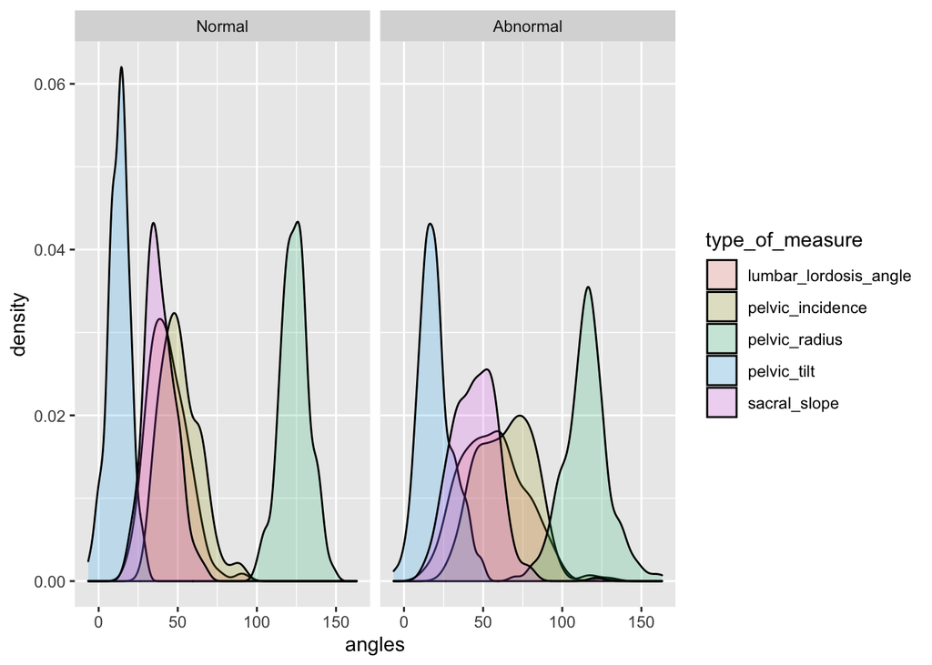

```r
ortho_df2 %>% ggplot(aes(angles, fill = type_of_measure)) + geom_density(alpha = 0.2)+ facet_grid(~class_2)
```

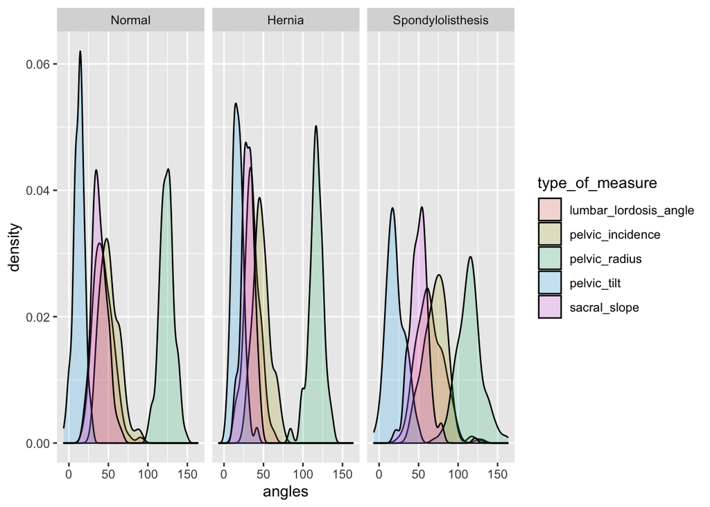

```r
ortho_df2 %>% ggplot(aes(angles, fill = type_of_measure)) + geom_density(alpha = 0.2)+ facet_grid(~class_3)
```

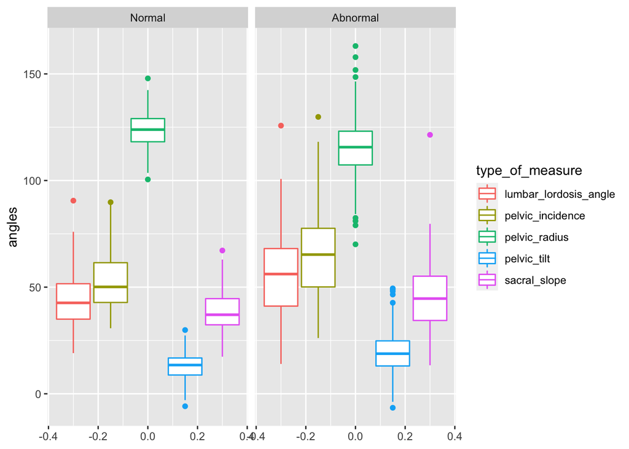

```r
ortho_df2 %>% ggplot(aes(y= angles, color = type_of_measure)) + geom_boxplot() + facet_grid(~class_2)
```

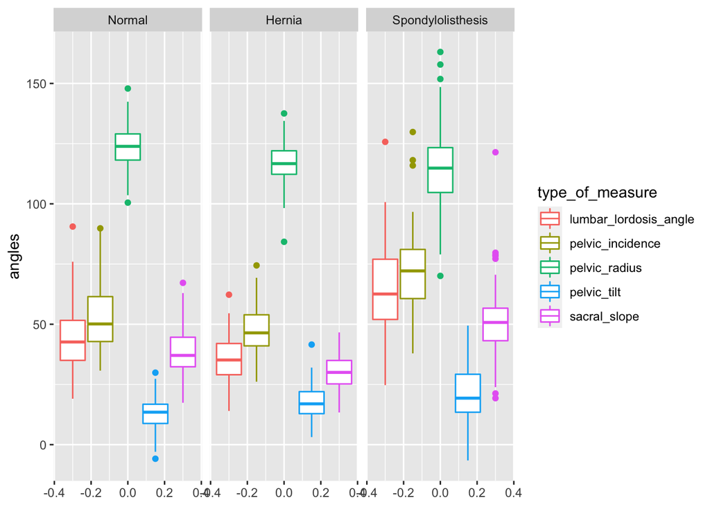

```r
ortho_df2 %>% ggplot(aes(y= angles, color = type_of_measure)) + geom_boxplot() + facet_grid(~class_3)
```

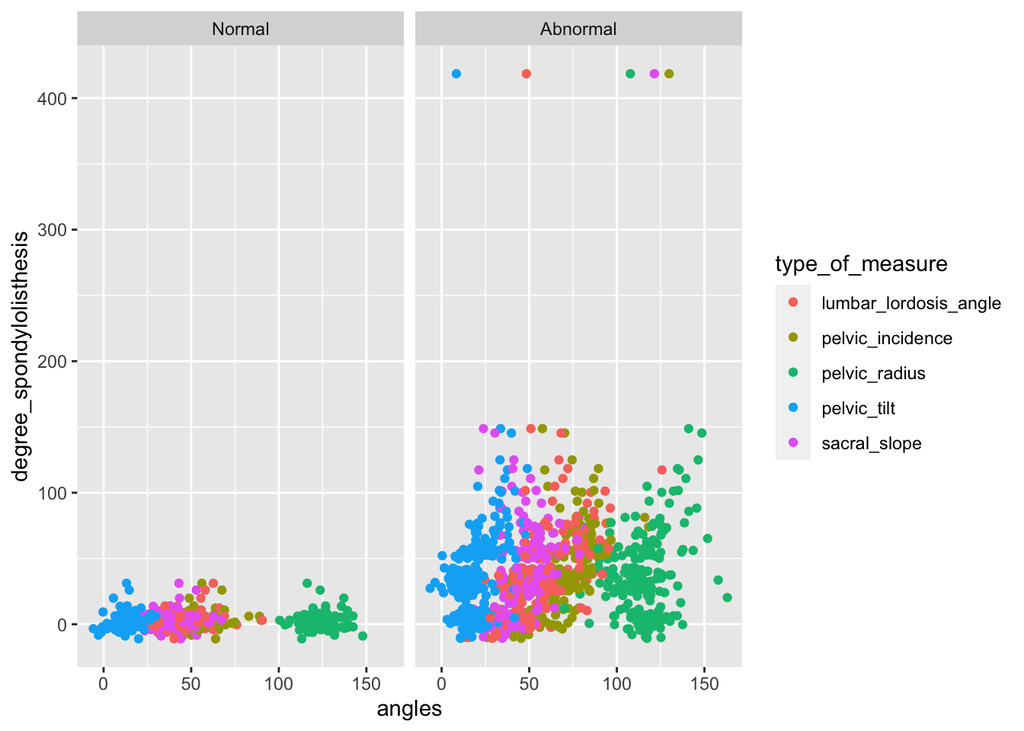

```r
ortho_df2 %>% ggplot(aes(x= angles,y = degree_spondylolisthesis,  color = type_of_measure)) + geom_point() + facet_grid(~class_2)
```

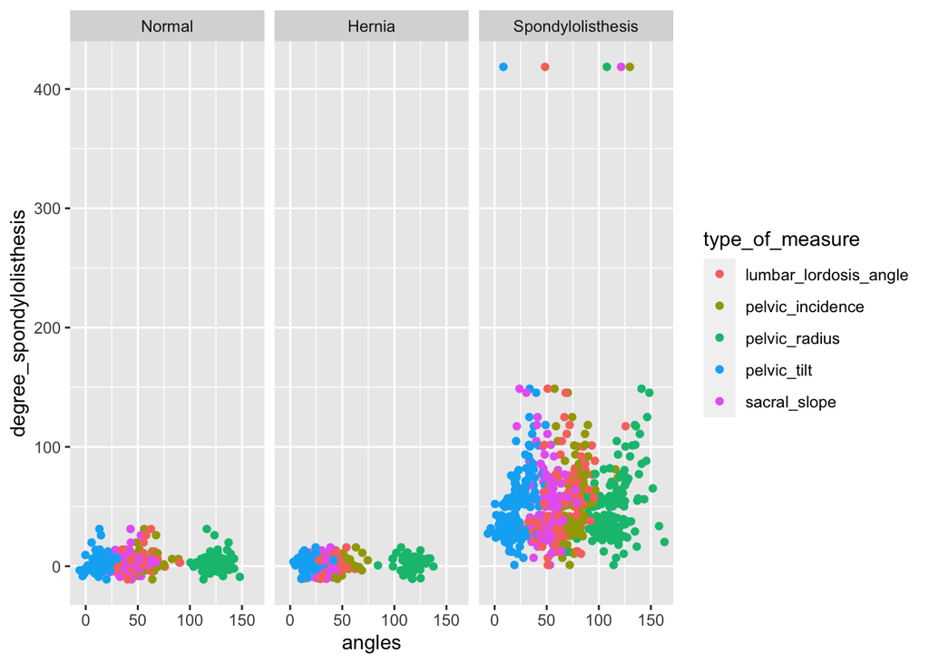

```r
ortho_df2 %>% ggplot(aes(x= angles,y = degree_spondylolisthesis,  color = type_of_measure)) + geom_point() + facet_grid(~class_3)
```

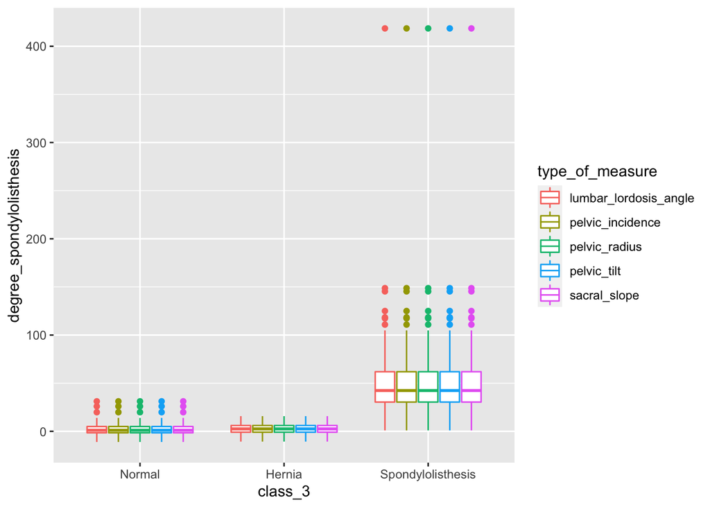

```r
ortho_df2 %>% ggplot(aes(x =class_3, y= degree_spondylolisthesis, color = type_of_measure)) + geom_boxplot()
```

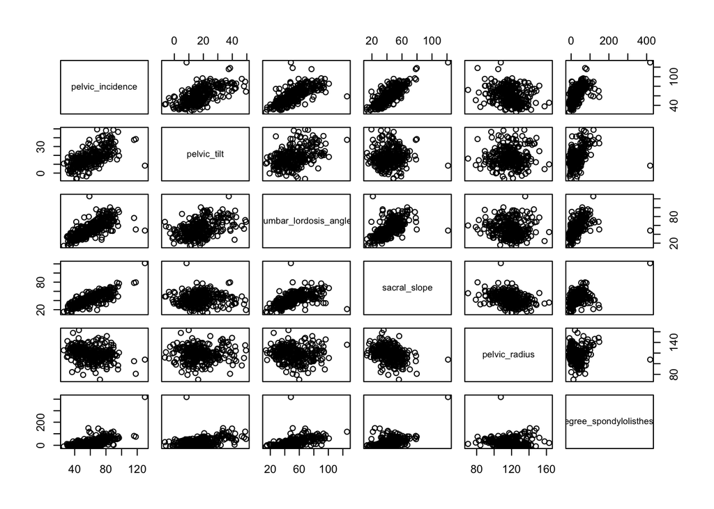

```r
ortho_df %>% select(where(is.numeric)) %>% pairs()
```

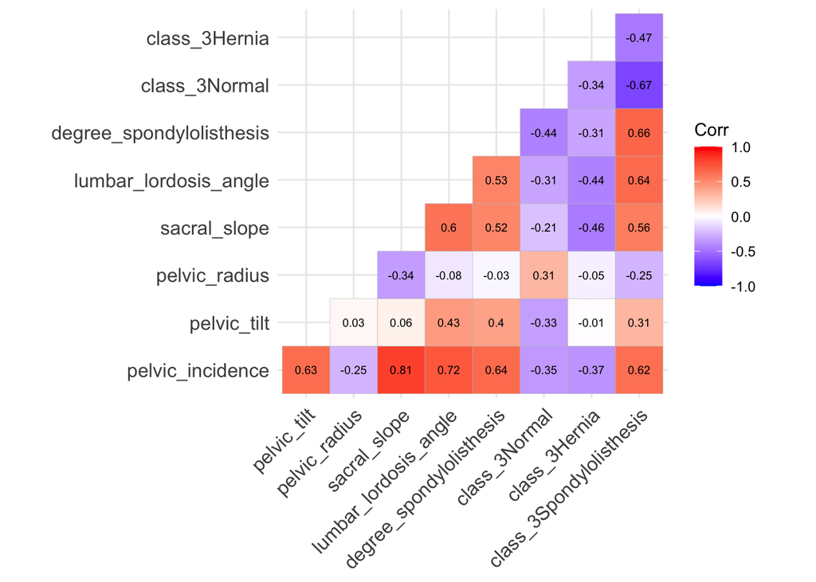

```r
model.matrix(~0. + pelvic_incidence+pelvic_tilt+pelvic_radius+sacral_slope+lumbar_lordosis_angle+ degree_spondylolisthesis + class_3, ortho_df) %>%cor() %>% ggcorrplot(lab=T, lab_size=2.5,type = "lower")
```

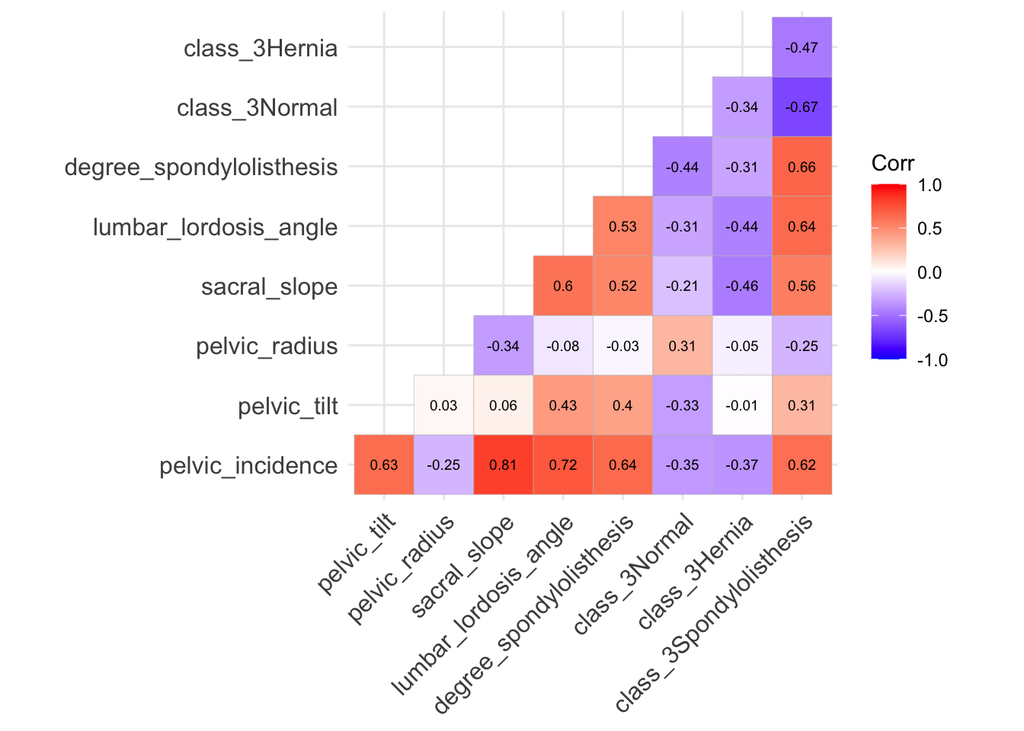

```r
model.matrix(~0. + pelvic_incidence+pelvic_tilt+pelvic_radius+sacral_slope+lumbar_lordosis_angle+ degree_spondylolisthesis + class_3, ortho_df) %>%cor() %>% ggcorrplot(lab=T, lab_size=2.5,type = "lower")
```